# Lab 05 - Predicting MHV Change

Jason Eastman

April 25, 2020

# Libraries

```r
library( dplyr )
library( knitr )
library( pander )
library( stargazer )
library( scales )
library( psych )

set.seed( 1234 )

s.type <- "html"
```

# Helper Functions

```r
panel.cor <- function(x, y, digits=2, prefix="", cex.cor)
{
    usr <- par("usr"); on.exit(par(usr))
    par(usr = c(0, 1, 0, 1))
    r <- abs(cor(x, y))
    txt <- format(c(r, 0.123456789), digits=digits)[1]
    txt <- paste(prefix, txt, sep="")
    if(missing(cex.cor)) cex <- 0.8/strwidth(txt)

    test <- cor.test(x,y)
    # borrowed from printCoefmat
    Signif <- symnum(test$p.value, corr = FALSE, na = FALSE,
                  cutpoints = c(0, 0.001, 0.01, 0.05, 0.1, 1),
                  symbols = c("***", "**", "*", ".", " "))

    text(0.5, 0.5, txt, cex = 1.5 )
    text(.7, .8, Signif, cex=cex, col=2)
}

panel.smooth <- function (x, y, col = par("col"), bg = NA, pch = par("pch"),
    cex = 0.5, col.smooth = "red", span = 2/3, iter = 3, ...)
{
    points(x, y, pch = 19, col = gray(0.7,0.2), bg = bg, cex = cex)
    ok <- is.finite(x) & is.finite(y)
    if (any(ok))
        lines(stats::lowess(x[ok], y[ok], f = span, iter = iter),
            col = col.smooth, lwd=2, ...)
}

# custom plot
jplot <- function( x1, x2, lab1="", lab2="", draw.line=T, ... )
{

    plot( x1, x2,
          pch=19,
          col=gray(0.6, alpha = 0.2),
          cex=0.5,
          bty = "n",
          xlab=lab1,
          ylab=lab2, cex.lab=1.5,
        ... )

    if( draw.line==T ){
        ok <- is.finite(x1) & is.finite(x2)
        lines( lowess(x2[ok]~x1[ok]), col="red", lwd=3 ) }

}
```

# Part 1 - Data

## *Similar to your previous lab, create a dataset that includes 2000 and 2010 census variables drop all rural census tracts.*

**Answer: See code and output below.**

```r
# Load datasets
d1 <- readRDS( "data/rodeo/LTDB-2000.rds" )
d2 <- readRDS( "data/rodeo/LTDB-2010.rds" )
md <- readRDS( "data/rodeo/LTDB-META-DATA.rds" )

d1 <- select( d1, - year )
d2 <- select( d2, - year )

# Merge datasets
d <- merge( d1, d2, by="tractid" )
d <- merge( d, md, by="tractid" )

# Drop all rural census tracts
d <- filter( d, urban == "urban" )

d.full <- d  # keep a copy so you don't have to reload

# Peek at new dataset
head(d)
```

|  | tractid | pop00.x | nhwht00 | nhblk00 | ntv00 | asian00 | hisp00 | haw00 | india00 | china00 | filip00 | japan00 | korea00 | viet00 | mex00 | pr00 | cuban00 | hu00 | vac00 | ohu00 | a18und00 | a60up00 | a75up00 | agewht00 | a15wht00 | a60wht00 | ageblk00 | a15blk00 | a60blk00 | … |
| --- | --- | --- | --- | --- | --- | --- | --- | --- | --- | --- | --- | --- | --- | --- | --- | --- | --- | --- | --- | --- | --- | --- | --- | --- | --- | --- | --- | --- | --- | --- |
| 1 | fips-01-001-020100 | 1920.975 | 1722.977 | 144.9981 | 28.99962 | 7.999895 | 11.99984 | 0.0000000 | 3.9999473 | 0.00000 | 0.9999868 | 0.9999868 | 1.999974 | 0.0000000 | 3.999947 | 1.999974 | 0.000000 | 768.9899 | 92.99877 | 675.9911 | 518.9932 | 259.9966 | 68.99909 | 1722.977 | 402.9947 | 244.9968 | 140.9981 | 30.99959 | 12.999828 | … |
| 2 | fips-01-001-020200 | 1892.000 | 671.000 | 1177.0000 | 12.00000 | 12.000000 | 16.00000 | 0.0000000 | 0.0000000 | 1.00000 | 3.0000000 | 1.0000000 | 6.000000 | 0.0000000 | 11.000000 | 1.000000 | 3.000000 | 731.0000 | 67.00000 | 664.0000 | 530.0000 | 282.0000 | 103.00000 | 671.000 | 156.0000 | 120.0000 | 1163.0000 | 302.00000 | 158.000000 | … |
| 3 | fips-01-001-020300 | 3339.000 | 2738.000 | 498.0000 | 16.00000 | 27.000000 | 55.00000 | 1.0000000 | 0.0000000 | 3.00000 | 3.0000000 | 8.0000000 | 2.000000 | 1.0000000 | 29.000000 | 16.000000 | 0.000000 | 1263.0000 | 61.00000 | 1202.0000 | 960.0000 | 594.0000 | 229.00000 | 2738.000 | 691.0000 | 499.0000 | 491.0000 | 132.00000 | 84.000000 | … |
| 4 | fips-01-001-020400 | 4556.000 | 4273.000 | 118.0000 | 23.00000 | 40.000000 | 101.00000 | 0.0000000 | 6.0000000 | 5.00000 | 7.0000000 | 13.0000000 | 8.000000 | 4.0000000 | 43.000000 | 32.000000 | 0.000000 | 1871.0000 | 111.00000 | 1760.0000 | 1123.0000 | 1009.0000 | 244.00000 | 4273.000 | 911.0000 | 982.0000 | 117.0000 | 39.00000 | 6.000000 | … |
| 5 | fips-01-001-020500 | 6053.912 | 5426.983 | 367.4790 | 36.10111 | 113.055609 | 95.23760 | 0.0000000 | 5.0000000 | 17.01011 | 21.0000000 | 20.0000000 | 31.015166 | 10.0101107 | 35.085941 | 28.060664 | 2.005055 | 2282.3435 | 80.39432 | 2201.9492 | 1871.2515 | 653.5570 | 156.43476 | 5426.983 | 1466.1586 | 630.2082 | 358.4639 | 121.50649 | 8.318486 | … |
| 6 | fips-01-001-020600 | 3272.000 | 2615.275 | 553.0823 | 25.18413 | 10.654825 | 63.92895 | 0.9686205 | 0.9686205 | 0.00000 | 0.9686205 | 1.9372410 | 1.937241 | 0.9686205 | 21.309650 | 8.717585 | 0.000000 | 1309.5748 | 139.48135 | 1170.0935 | 992.8360 | 430.0675 | 116.23446 | 2615.275 | 677.0657 | 356.4523 | 540.4902 | 176.28893 | 65.866196 | … |

## *Create a variable that measures the growth of median home value from 2000 to 2010. Omit cases that have a median home value less than $10,000 in 2000. Omit cases with growth rates above 200%.*

**ANSWER: See code and output below.**

```r
 # adjust 2000 home values for inflation
mhv.00 <- d$mhmval00 * 1.28855
mhv.10 <- d$mhmval12

# change in MHV in dollars
mhv.change <- mhv.10 - mhv.00

# drop low 2000 median home values
# to avoid unrealistic growth rates.
#
# tracts with homes that cost less than
# $10,000 are outliers
mhv.00[ mhv.00 < 1000 ] <- NA

# change in MHV in percent
mhv.growth <- 100 * ( mhv.change / mhv.00 )

# drop high growth rate above 200%
# to avoid unrealistic growth rates.
#
# tracts with growth rates that are
# above 200% are outliers
mhv.growth[ mhv.growth > 200 ] <- NA

# Add variables into dataset
d$mhv.00 <- mhv.00
d$mhv.10 <- mhv.10
d$mhv.change <- mhv.change
d$mhv.growth <- mhv.growth

# Peek at new variables
peek_at_data <- d %>%
  select(tractid, mhv.00, mhv.10, mhv.change, mhv.growth)

head(peek_at_data)
```

|  | tractid | mhv.00 | mhv.10 | mhv.change | mhv.growth |
| --- | --- | --- | --- | --- | --- |
| 1 | fips-01-001-020100 | 98702.93 | 121500 | 22797.07 | 23.09665 |
| 2 | fips-01-001-020200 | 93935.30 | 130500 | 36564.70 | 38.92542 |
| 3 | fips-01-001-020300 | 102955.15 | 118700 | 15744.85 | 15.29293 |
| 4 | fips-01-001-020400 | 115711.79 | 133500 | 17788.21 | 15.37286 |
| 5 | fips-01-001-020500 | 150236.59 | 174500 | 24263.41 | 16.15013 |
| 6 | fips-01-001-020600 | 90713.92 | 129600 | 38886.08 | 42.86672 |

# Part 2 - Community Health

## *Reconstruct your three community health scales from Lab 02.*

**NOTE:** I completely reworked my Lab 02 while working on this lab, as I understand this much more. I chose to keep similar variables and latent constructs even though the cronbach alpha scores were not that high for experimental sake.

My Three Instruments and their Indepedent Variables

- Economic Strength of the Community:
  - persons with at least a four-year college degree (col)
  - Median HH Income, Total (hinc)
  - employed persons 16 years and over (empclf)
- Vulnerability of the Community, Low-Income Hispanics:
  - Hispanics in poverty (nhpov)
  - persons who speak English not well (lep)
  - persons with high school degree or less (hs)
- Vulnerability of the Community, Single Female-Lead Homes:
  - Female-Headed Families with Children (fhh)
  - Widowed, Divorced and Separated (wds)
  - females in labor force (flabf)

```r
dMaster <- d  # keep a copy so you don't have to reload
```

```r
d <- dMaster

# Create subset , keeping only values we want
d <- select( d, tractid,
             hs00, hs12, ag25up00, ag25up12, col00, col12,
             empclf00, empclf12, hinc00, hinc12, nhpov00,
             nhpov12, dhpov00, dhpov12, family00, family12,
             lep00, lep12, fhh00, fhh12, wds00, wds12,
             flabf00, flabf12, clf00, clf12, ag5up00, ag5up12,
             "mhv.00", "mhv.10", "mhv.change", "mhv.growth",
             cbsa, cbsaname )

# Create new variables
d <-
  d %>%
  mutate( # Below are percent change from 2000 to 2010
          p.hs.change = 100 * ( hs12 - hs00 ) / (hs00 + 0.01),
          p.col.change = 100 * ( col12 - col00 ) / (col00 + 0.01),
          p.emp.change = 100 * ( empclf12 - empclf00 ) / (empclf00 + 0.01),
          p.hinc.change = 100 * ( hinc12 - hinc00 ) / (hinc00 + 0.01),
          p.hisp.pov.change = 100 * ( nhpov12 - nhpov00 ) / ( nhpov00 + 0.01 ),
          p.lep.change = 100 * ( lep12 - lep00 ) / (lep00 + 0.01),
          p.fhh.change = 100 * ( fhh12 - fhh00 ) / (fhh00 + 0.01),
          p.wds.change = 100 * ( wds12 - wds00 ) / (wds00 + 0.01),
          p.flabf.change = 100 * ( flabf12 - flabf00 ) / (flabf00 + 0.01),
          # Below is the percent within a population
          hs.rate00 = 100 * ( hs00 / ( ag25up00 + 0.01 )),
          col.rate00 = 100 * ( col00 / ( ag25up00 + 0.01 )),
          emp.rate00 = 100 * ( empclf00 / ( clf00 + 0.01 )),
          hisp.pov.rate00 = 100 * ( nhpov00 / (dhpov00 + 0.01 )),
          lep.rate00 = 100 * ( lep00 / ( ag5up00 + 0.01 )),
          fhh.rate00 = 100 * ( fhh00 / ( family00 + 0.01 )),
          wds.rate00 = 100 * ( wds00 / ( ag25up00 + 0.01 )),
          flabf.rate00 = 100 * ( flabf00 / (clf00 + 0.01 ))
          )

# Remove outliers that came from dividing a large number by 0.01
d[which(d$p.hs.change %in% boxplot(d$p.hs.change, plot=FALSE)$out), "p.hs.change"] <- NA
d[which(d$p.col.change %in% boxplot(d$p.col.change, plot=FALSE)$out),"p.col.change"] <- NA
d[which(d$p.emp.change %in% boxplot(d$p.emp.change, plot=FALSE)$out),"p.emp.change"] <- NA
d[which(d$p.hinc.change %in% boxplot(d$p.hinc.change, plot=FALSE)$out),"p.hinc.change"] <- NA
d[which(d$p.hisp.pov.change %in% boxplot(d$p.hisp.pov.change, plot=FALSE)$out),"p.hisp.pov.change"] <- NA
d[which(d$p.lep.change %in% boxplot(d$p.lep.change, plot=FALSE)$out),"p.lep.change"] <- NA
d[which(d$p.fhh.change %in% boxplot(d$p.fhh.change, plot=FALSE)$out),"p.fhh.change"] <- NA
d[which(d$p.wds.change %in% boxplot(d$p.wds.change, plot=FALSE)$out),"p.wds.change"] <- NA
d[which(d$p.flabf.change %in% boxplot(d$p.flabf.change, plot=FALSE)$out),"p.flabf.change"] <- NA
d[which(d$hs.rate00 %in% boxplot(d$hs.rate00, plot=FALSE)$out),"hs.rate00"] <- NA
d[which(d$col.rate00 %in% boxplot(d$col.rate00, plot=FALSE)$out),"col.rate00"] <- NA
d[which(d$emp.rate00 %in% boxplot(d$emp.rate00, plot=FALSE)$out),"emp.rate00"] <- NA
d[which(d$hisp.pov.rate00 %in% boxplot(d$hisp.pov.rate00, plot=FALSE)$out),"hisp.pov.rate00"] <- NA
d[which(d$lep.rate00 %in% boxplot(d$lep.rate00, plot=FALSE)$out),"lep.rate00"] <- NA
d[which(d$fhh.rate00 %in% boxplot(d$fhh.rate00, plot=FALSE)$out),"fhh.rate00"] <- NA
d[which(d$wds.rate00 %in% boxplot(d$wds.rate00, plot=FALSE)$out),"wds.rate00"] <- NA
d[which(d$flabf.rate00 %in% boxplot(d$flabf.rate00, plot=FALSE)$out),"flabf.rate00"] <- NA

# Round the entire dataset to 2 digits
is.num <- sapply(d, is.numeric)
d[is.num] <- lapply(d[is.num], round, 2)

head(d)
```

|  | tractid | hs00 | hs12 | ag25up00 | ag25up12 | col00 | col12 | empclf00 | empclf12 | hinc00 | hinc12 | nhpov00 | nhpov12 | dhpov00 | dhpov12 | family00 | family12 | lep00 | lep12 | fhh00 | fhh12 | wds00 | wds12 | flabf00 | flabf12 | clf00 | clf12 | ag5up00 | ag5up12 | … |
| --- | --- | --- | --- | --- | --- | --- | --- | --- | --- | --- | --- | --- | --- | --- | --- | --- | --- | --- | --- | --- | --- | --- | --- | --- | --- | --- | --- | --- | --- | --- |
| 1 | fips-01-001-020100 | 634.99 | 687 | 1226.98 | 1206 | 192.00 | 287 | 825.99 | 858 | 36685.00 | 56500 | 0 | 0 | 0.00 | 0 | 531.99 | 464 | 0.00 | 0 | 59.00 | 25 | 237.00 | 334 | 383.99 | 424 | 871.99 | 878 | 1780.98 | 1739 | … |
| 2 | fips-01-001-020200 | 740.00 | 745 | 1157.00 | 1442 | 170.00 | 349 | 722.00 | 880 | 30298.00 | 41250 | 0 | 0 | 0.00 | 53 | 494.00 | 482 | 8.00 | 28 | 121.00 | 124 | 314.00 | 509 | 392.00 | 560 | 802.00 | 1010 | 1774.00 | 2102 | … |
| 3 | fips-01-001-020300 | 990.00 | 1006 | 2130.00 | 2082 | 478.00 | 292 | 1414.00 | 1408 | 46731.00 | 43088 | 6 | 0 | 93.00 | 56 | 920.00 | 790 | 17.00 | 12 | 118.00 | 108 | 577.00 | 656 | 677.00 | 685 | 1456.00 | 1423 | 3047.00 | 3004 | … |
| 4 | fips-01-001-020400 | 1477.00 | 1242 | 3072.00 | 2998 | 708.00 | 785 | 2114.00 | 1825 | 46142.00 | 54503 | 30 | 0 | 63.00 | 114 | 1376.00 | 1209 | 0.00 | 2 | 102.00 | 89 | 542.00 | 955 | 1062.00 | 934 | 2191.00 | 2005 | 4281.00 | 4132 | … |
| 5 | fips-01-001-020500 | 1257.35 | 1940 | 3785.21 | 6351 | 1214.09 | 2569 | 2905.82 | 5037 | 58886.27 | 65027 | 23 | 0 | 49.30 | 266 | 1746.90 | 2520 | 33.03 | 60 | 144.64 | 395 | 608.70 | 1751 | 1316.80 | 2643 | 2955.17 | 5224 | 5601.03 | 9706 | … |
| 6 | fips-01-001-020600 | 1178.81 | 1118 | 1976.95 | 2136 | 317.71 | 438 | 1496.52 | 1426 | 33699.00 | 52639 | 0 | 174 | 30.03 | 357 | 904.69 | 886 | 56.18 | 74 | 123.01 | 167 | 553.08 | 571 | 747.78 | 837 | 1583.69 | 1583 | 3031.78 | 3317 | … |

## *Run three bivariate regressions predicting MHV growth with each community health metric, and one regression with all three metrics together.*

### Instrument 1: Economic Strength of the Community

**Summary**

```r
df1 <- data.frame(HHIncome.00=d$hinc00,
                  Employment.Rate.00=d$emp.rate00,
                  College.Rate.00=d$col.rate00,
                  MHV.Growth=d$mhv.growth)

stargazer( df1,
           type=s.type,
           digits=0,
           summary.stat = c("min", "p25","median","mean","p75","max") )
```

| Statistic | Min | Pctl(25) | Median | Mean | Pctl(75) | Max |
| --- | --- | --- | --- | --- | --- | --- |
| HHIncome.00 | 2,499 | 33,000 | 43,825 | 47,657 | 58,036 | 200,001 |
| Employment.Rate.00 | 85 | 93 | 96 | 95 | 97 | 100 |
| College.Rate.00 | 0 | 12 | 21 | 25 | 35 | 72 |
| MHV.Growth | -97 | 6 | 25 | 29 | 49 | 200 |

**Cronbach’s Alpha Score**

```r
a1 <- psych::alpha( df1, check.keys=TRUE )$total$std.alpha
a1
```

```
## [1] 0.6333639
```

**Correlation Plot**

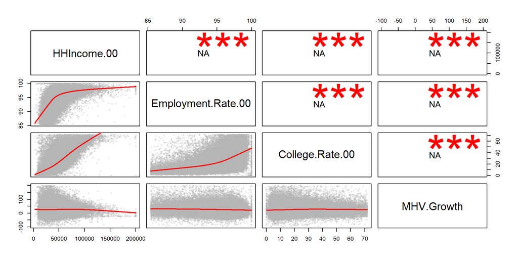

```r
pairs( df1, lower.panel=panel.smooth, upper.panel=panel.cor )
```

**Regression Analysis**

```r
m1 <- lm( MHV.Growth ~ HHIncome.00 + Employment.Rate.00 + College.Rate.00, data=df1)

stargazer( m1,
           type=s.type, digits=2,
           omit.stat = c("rsq","f") )
```

|  | *Dependent variable:* |
| --- | --- |
|  | MHV.Growth |
| HHIncome.00 | -0.0001*** |
|  | (0.0000) |
| Employment.Rate.00 | -1.61*** |
|  | (0.06) |
| College.Rate.00 | 0.31*** |
|  | (0.01) |
| Constant | 178.06*** |
|  | (5.26) |
| Observations | 54,122 |
| Adjusted R<sup>2</sup> | 0.02 |
| Residual Std. Error | 33.54 (df = 54118) |
| *Note:* | p<0.1; p<0.05; p<0.01 |

### Instrument 2: Vulnerability of the Community, Low-Income Hispanics

**Summary**

```r
df2 <- data.frame(Hisp.Pov.Rate.00=d$hisp.pov.rate00,
                  Low.English.Rate.00=d$lep.rate00,
                  High.School.Rate.00=d$hs.rate00,
                  MHV.Growth=d$mhv.growth)

stargazer( df2,
           type=s.type,
           digits=0,
           summary.stat = c("min", "p25","median","mean","p75","max") )
```

| Statistic | Min | Pctl(25) | Median | Mean | Pctl(75) | Max |
| --- | --- | --- | --- | --- | --- | --- |
| Hisp.Pov.Rate.00 | 0 | 0 | 10 | 14 | 23 | 62 |
| Low.English.Rate.00 | 0 | 0 | 1 | 2 | 3 | 11 |
| High.School.Rate.00 | 0 | 32 | 47 | 47 | 61 | 100 |
| MHV.Growth | -97 | 6 | 25 | 29 | 49 | 200 |

**Cronbach’s Alpha Score**

```r
a2 <- psych::alpha( df2, check.keys=TRUE )$total$std.alpha
a2
```

```
## [1] 0.4114157
```

**Correlation Plot**

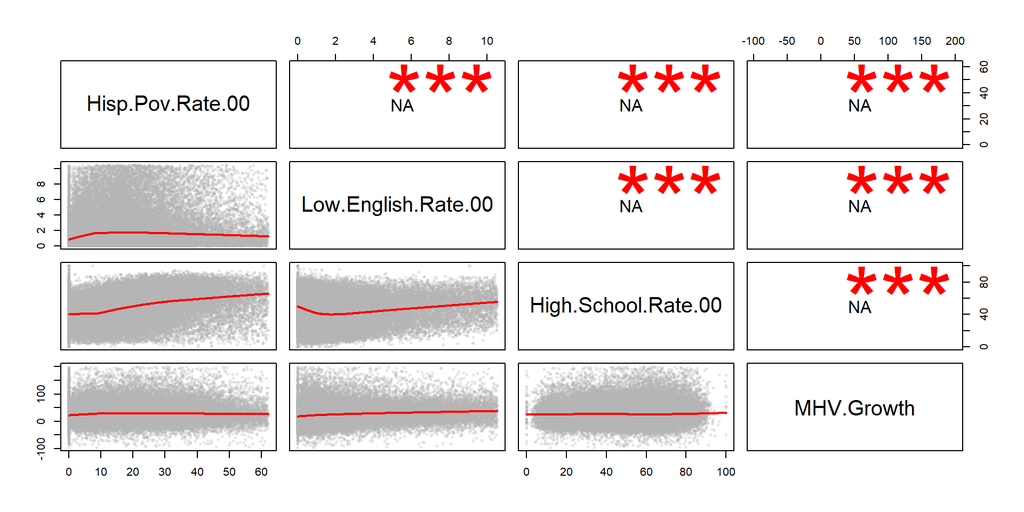

```r
pairs( df2, lower.panel=panel.smooth, upper.panel=panel.cor )
```

**Regression Analysis**

```r
m2 <- lm( MHV.Growth ~ Hisp.Pov.Rate.00 + Low.English.Rate.00 + High.School.Rate.00, data=df2)

stargazer( m2,
           type=s.type, digits=2,
           omit.stat = c("rsq","f") )
```

|  | *Dependent variable:* |
| --- | --- |
|  | MHV.Growth |
| Hisp.Pov.Rate.00 | 0.07*** |
|  | (0.01) |
| Low.English.Rate.00 | 1.95*** |
|  | (0.07) |
| High.School.Rate.00 | -0.09*** |
|  | (0.01) |
| Constant | 26.26*** |
|  | (0.40) |
| Observations | 49,588 |
| Adjusted R<sup>2</sup> | 0.02 |
| Residual Std. Error | 32.96 (df = 49584) |
| *Note:* | p<0.1; p<0.05; p<0.01 |